# KL2d_vonKarman_lognormal

## Demo of Karhunen-Loeve approach to generating stochastic slip patterns

### Using lognormal distribution rather than Gaussian

### Illustrating von Karman autocorrelation function on rectangular fault and CSZ

#### Randy LeVeque, Draft of 12 March 2016,

### Overview

- A fault is subdivided into many small rectangular patches (subfaults). Constant slip will be assigned to each patch (and eventually the Okada model will be applied to each to generate seafloor deformation for the tsunami model). We will number the subfaults from `k = 0` to `k = N` and want to assign `slip[k]` meters of slip to the `k`th subfault to create a random realization with desired statistics.
- Assume we want the slip on each patch to be lognormally distributed with mean $\mu_k = $ `mean_slip[k]` and standard deviation $\sigma_k = $ `sigma_slip[k]`. Moreover, assume that the slips are to be correlated with the covariance between subfaults `i` and `j` given by $\sigma_i\sigma_j C_{ij} = \hat C_{ij} = $ `Cov[i,j]`. Here $C_{ij}$ is a symmetric correlation matrix with $C_{ii} = 1$ and $C_{ij}$ decaying as the distance between the subfaults increases.
- Note that the correlation $C_{ij}$ can be defined by any autocorrelation function (ACF). We define this to be some function of $r$ which represents a scaled distance between subfaults $i$ and $j$, e.g. via $$ r = \sqrt{(D_{strike}/r_{strike})^2 + (D_{dip}/r_{dip})^2} $$ where $D_{strike}$ and $D_{dip}$ are distances in the strike and dip direction respectively between the subfaults and $r_{strike}$ and $r_{dip}$ are correlation lengths.
- Compute the eigenvalues $\lambda_k$ and eigenvectors $v_k$ of $\hat C = V\Lambda V^T$. Note that each eigenvector can be viewed as a slip pattern on the fault, since it has one component for each subfault. Also note that $V^{-1} = V^T$ since $\hat C$ is symmetric.
- The **key idea** is that to generate random slip patterns with the desired covariance, we can generate *independent* normally distributed random numbers $z_k \sim N(0,1)$ with mean 0 and standard deviation 1 (which means $E[zz^T] = I$, the identity matrix) and then set the vector of slips to: $$ s = \mu + \sum_{k=1}^N z_k \sqrt{\lambda_k} v_k. $$ This is the *Karhunen-Loeve (K-L) expansion*. Mathematically this works to give the right statistics because we can write $$ s = \mu + V\Lambda^{1/2} z, $$ and so the covariance of $s$ will be: $$ E[(s-\mu)(s-\mu)^T] = E[V\Lambda^{1/2}zz^T \Lambda^{1/2}V^T] = V\Lambda V^T E[zz^T] = \hat C. $$

A Gaussian random field might have negative slips on some subfaults. Instead we can generate a lognormal random field in which all the slips are nonnegative by exponentiating the K-L expansion. In this case we first choose the desired mean and covariance matrix for the slip, $\mu^s$ and $\sigma^s$ and then compute the necessary mean $\mu^g$ and covariance matrix $\sigma^g$ for the Gaussian to be generated by the K-L expansion, using the fact that if $g$ is a random variable from ${\cal N}(\mu^g, \sigma^g)$, then $\exp(g)$ is lognormal with mean and covariance matrix given by: $$\mu_i^s = \exp(\mu_i^g + \sigma_{ii}^g/2), \qquad \sigma_{ij}^s = \mu_i\mu_j(\exp(\sigma_{ij}^g) - 1).$$ Hence we can solve for $$ \sigma_{ij}^g = \log(\sigma_{ij}^s/\mu_i^s\mu_j^s + 1),$$ $$ \mu_i^g = \log(\mu_i^s) - \frac 1 2 \sigma_{ii}^g.$$

Since it is easy to generate $N(0,1)$ random numbers, we can easily generate realizations with the right statistical properties. (Provided the underlying epistemic assumptions are valid, that real slip is a sample from a lognormal field, and we have the right parameters such as $\mu^s, \sigma^s,$ and the correlation function.)

Note that the sum in the K-L expansion has $N$ terms, the number of subfaults. So these realizations all lie in an $N$-dimensional space, but the distribution is a joint Gaussian in this space in terms of the random variables $z_k$. So it is easy to sample.

However, it is still a space with a very high dimension $N$, that would be difficult to explore using Monte-Carlo simulation.

But there is another advantage to using the K-L expansion to represent the slip: if the slip is assumed to be highly correlated then the eigenvalues $\lambda_k$ decay rapidly. The eigenvectors corresponding to the largest eigenvalues are smoothest, and those corresponding to small $\lambda_k$ are more highly oscillatory. If the correlation length is large then the highly oscillatory modes have smaller weights $z_k\sqrt{\lambda_k}$ than the smooth modes, and the resulting slip patterns should be smooth. This means we can truncate the K-L expansion after a few terms since these dominate the sum. Then we have a much smaller dimensional stochastic space to explore.

### Things to adjust:

- The correlation function, and Hurst exponent `H` for von Karman,
- The correlation lengths,
- The value $\alpha$ for standard deviation $\sigma_i = \alpha \mu_i$ on each subfault,
- Taper of mean towards edges of fault,
- Number of terms to use in K-L expansion,

#### Contents

- Rectangular fault
- Cascadia Subduction Zone

##### Set up notebook and import some Python modules...

```python
%pylab inline
```

```
WARNING: pylab import has clobbered these variables: ['power', 'f', 'seed']
`%matplotlib` prevents importing * from pylab and numpy
```

```python
import dtopotools # local version slightly different than in geoclaw currently
import sys, os
#import pandas as pd
from numpy import random
```

### Function to compute distances between subfaults in 2D:

Note that we define the distance in the dip direction $D_{dip}$ based on the difference in depth between two subfaults and the define $D_{strike} = \sqrt{D^2 - D_{dip}^2}$, where $D$ is the Euclidean distance between the subfaults. This is an attempt to define these to make sense also for curving faults such as CSZ.

```python
def compute_subfault_distances(fault):
    """
    Estimate the distance between subfaults i and j for every pair in the list
    fault.subfaults.

    :Inputs:
      -  *fault* of class dtopotools.Fault or some subclass,

    :Outputs:
      - *D* array of Euclidean distances based on longitudes, latitudes, and depths
      - *Dstrike* array of estimated distances along strike direction
      - *Ddip* array of estimated distances along dip direction
    with D**2 = Dstrike**2 + Ddip**2 to within roundoff.

    For each array, the [i,j] entry is distance from subfault i to j when
    ordered in the order the subfaults appear in the list fault.subfaults.

    Distance in dip direction based on differences in depth.

    """

    import numpy
    from numpy import pi,sqrt,sin,cos,tan
    rad = pi/180.       # conversion factor from degrees to radians
    rr = 6.378e6        # radius of earth
    lat2meter = rr*rad  # conversion factor from degrees latitude to meters

    nsubfaults = len(fault.subfaults)
    D = numpy.zeros((nsubfaults,nsubfaults))
    Dstrike = numpy.zeros((nsubfaults,nsubfaults))
    Ddip = numpy.zeros((nsubfaults,nsubfaults))
    for i,si in enumerate(fault.subfaults):
        xi = si.longitude
        yi = si.latitude
        zi = si.depth
        for j,sj in enumerate(fault.subfaults):
            xj = sj.longitude
            yj = sj.latitude
            zj = sj.depth
            dx = abs(xi-xj)*cos(0.5*(yi+yj)*pi/180.) * lat2meter
            dy = abs(yi-yj) * lat2meter
            dz = abs(zi-zj)

            # Euclidean distance:
            D[i,j] = sqrt(dx**2 + dy**2 + dz**2)

            # estimate distance down-dip based on depths:
            dip = 0.5*(si.dip + sj.dip)
            ddip1 = dz / sin(dip*pi/180.)
            Ddip[i,j] = ddip1
            if Ddip[i,j] > D[i,j]:
                # should not happen...
                if 0:
                    print "i,j,dx,dy,dz: ",i,j,dx,dy,dz
                    print "*** Ddip = %s, D = %s" % (Ddip[i,j], D[i,j])

            # compute distance in strike direction to sum up properly:
            dstrike2 = max(D[i,j]**2 - Ddip[i,j]**2, 0.)
            Dstrike[i,j] = sqrt(dstrike2)

    return D,Dstrike,Ddip
```

## Set up a rectangular fault:

```python
length = 200.e3 # meters
width = 100.e3
dip = 13.
depth = 10.e3

coordinate_specification = 'top center'
input_units = {'slip': 'm', 'depth': 'm', 'length': 'm', 'width': 'm'}

subfault = dtopotools.SubFault()
#subfault.coordinate_specification = coordinate_specification
subfault.longitude = 0.
subfault.latitude = 0.
subfault.depth = depth
subfault.strike = 0.
subfault.length = length
subfault.width = width
subfault.dip = dip
subfault.rake = 90.
subfault.slip = 1.

base_fault = dtopotools.Fault([subfault], input_units, coordinate_specification)

# plot the geometry:
#base_fault.plot_subfaults()
```

##### Subdivide the fault into subfaults for illustration...

Here $N = $ `nstrike * ndip`.

```
Subdivided fault has N = 861 subfaults
```

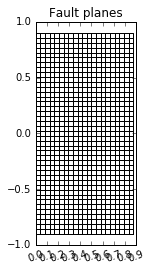

```python
# subdivide the subfault into array of nstrike by ndip subfaults:
nstrike = 41
ndip = 21
fault = dtopotools.SubdividedPlaneFault(subfault, nstrike, ndip)
fault.plot_subfaults()
N = len(fault.subfaults)
print "Subdivided fault has N = %s subfaults" % N
new_fault = fault # for compatibility with old names
```

##### Compute the distance between each pair of subfaults

The function used below computes a distance matrix `D` so that `D[i,j]` is the Euclidean distance between the faults, and also `Dstrike` and `Ddip`, the distances in the strike and dip directions as estimated based on the depth of each subfault.

```python
D, Dstrike, Ddip = compute_subfault_distances(new_fault)
```

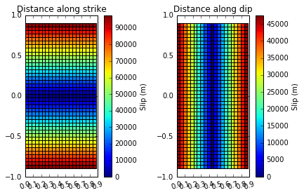

```python
# for debugging, plot distances from central subfault
i = int(N / 2)
for j,s in enumerate(new_fault.subfaults):
    s.slip = Dstrike[i,j]
ax1 = axes([.1,.1,.4,.8])
new_fault.plot_subfaults(ax1,slip_color=True)
title('Distance along strike')

for j,s in enumerate(new_fault.subfaults):
    s.slip = Ddip[i,j]
ax2 = axes([.6,.1,.4,.8])
new_fault.plot_subfaults(ax2,slip_color=True)
title('Distance along dip')
```

The plots above show the distance from each subfault to the central subfault as an example, obtained by plotting one row of the distance matrices `Dstrike` and `Ddip`. (The colorscale is meters along the fault, not slip!)

##### Create the desired correlation matrix...

Based on these distances and the assumption that there the correlation length in the strike and dip directions are some fraction of the width in these directions. This can be adjusted.

Here we use the von Karman autocorrelation function.

Is this the right formula? Note that it agrees with the exponential ACF for Hurst exponent 0.5, as expected.

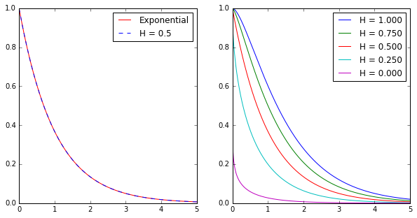

```python
from scipy.special import kv as Bessel # Modified Bessel function of second kind

delta = 1e-7  # fudge factor to avoid divide by zero

#Define von Karmen ACF in terms of G_H(r) where H is the Hurst exponent:
G = lambda r,H: (r+delta)**H * Bessel(H,(r+delta))
vonKarman = lambda r,H: G(r,H)/G(delta,H)

# Plots:
r = linspace(delta,5,501)

figure(figsize=(10,5))
subplot(121)
plot(r, exp(-r),'r', label='Exponential')
plot(r, vonKarman(r,0.5), 'b--', label='H = 0.5')
legend()

subplot(122)
for H in linspace(1,0,5):
    plot(r, vonKarman(r,H), label='H = %5.3f' % H)
legend()
```

##### Create the desired correlation matrix...

Based on these distances and ACF defined above.

```python
# make correlation matrix:
# with correlation lengths Lstrike and Ldip:
Lstrike = 0.4 * length
Ldip = 0.4 * width
H = 0.3  # Hurst exponent

print "Correlation lengths: Lstrike = %g, Ldip = %g" % (Lstrike,Ldip)
print "Hurst exponent = %4.2f" % H
r = sqrt((Dstrike/Lstrike)**2 + (Ddip/Ldip)**2)
C = vonKarman(r,H)

# Alternatives:
#C = exp(-r) # Exponential
#C = exp(-r**2) # Gaussian
```

```
Correlation lengths: Lstrike = 80000, Ldip = 40000
Hurst exponent = 0.30
```

To get an idea of what the correlation looks like, plot the `i`th row of `C`, which shows the correlation of each subfault with subfault number `i`. Choose `i` to be the subfault in the middle of the original fault plane:

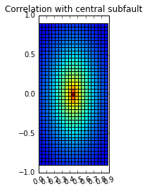

```python
# for debugging, plot correlation with central subfault
i = int(N / 2)
for j,s in enumerate(new_fault.subfaults):
    s.slip = C[i,j]

new_fault.plot_subfaults(slip_color=True, colorbar_shrink=0)
title('Correlation with central subfault')
```

The above plot shows the correlation $C_{ij}$ of each subfault $j$ with subfault in the center, numbered $i = N/2$, and gives an indication of the correlation lengths set above relative to the dimension of the fault.

## Compute desired covariance matrix...

### Choose a taper:

Here use a taper only at the down-dip edge.

```
Maximum depth of fault plane is 32495.1 meters
```

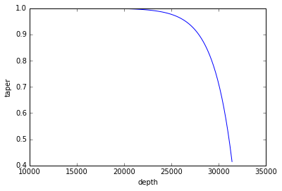

```python
max_depth = depth + width * sin(dip*pi/180.)
print 'Maximum depth of fault plane is %g meters' % max_depth
tau = lambda depth: 1. - exp((depth - max_depth)/2000.)

d = linspace(depths.min(), depths.max(), 100)
plot(d, tau(d))
xlabel('depth')
ylabel('taper')
```

```
Mean slip = 11.1406367267 meters
After tapering and rescaling, Mw = 8.6
```

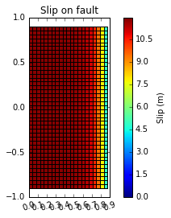

```python
Mw_desired = 8.6

subfaults = new_fault.subfaults
rigidity = subfaults[0].mu  # default rigidity

n = len(subfaults)
lengths = array([s.length for s in subfaults])
widths = array([s.width for s in subfaults])
depths = array([s.depth for s in subfaults])
areas = lengths*widths
total_area = sum(areas)

Mo_desired = 10.**(1.5*Mw_desired + 9.05)

mean_slip_scalar = Mo_desired / (rigidity * total_area)
print "Mean slip = %s meters" % mean_slip_scalar

# Turn this into a constant vector:
mean_slip = mean_slip_scalar * ones(n)

# Apply taper if desired:

depths = array([s.depth for s in new_fault.subfaults])
mean_slip *= tau(depths)

# rescale to have desired total slip:
mean_slip = mean_slip / sum(mean_slip) * n * mean_slip_scalar

for j,s in enumerate(new_fault.subfaults):
    s.slip = mean_slip[j]
new_fault.plot_subfaults(slip_color=True)

print "After tapering and rescaling, Mw = %g" % new_fault.Mw()
```

Assume the standard deviation is some fraction $\alpha$ of the mean on each subfault:

```python
alpha = 0.5
sigma_slip = alpha * mean_slip
```

## Lognormal:

The covariance matrix desired is $\hat C = S C S$, where $S = $diag$(\sigma)$, i.e. $\hat C_{ij} = \sigma_i\sigma_jC_{ij}$ where $C$ is the correlation matrix.

This can be achieved by generating joint-normal values with covariances $C^g_{ij} = log(\hat C_{ij}/(\mu_i\mu_j) +1)$ and means $\mu_i^g = \log(\mu_i) - C^g_{ii}/2$, and then exponentiating.

```python
Cov = sigma_slip * (C*sigma_slip).T
Cov_g = log((sigma_slip/mean_slip) * (C*(sigma_slip/mean_slip)).T + 1.)
mean_slip_g = log(mean_slip) - diag(Cov_g)/2.
```

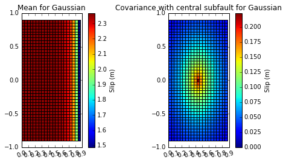

```python
# for debugging, plot covariance with central subfault
i = int(N / 2)

figure(figsize=(8,4))
ax = subplot(121)
for j,s in enumerate(new_fault.subfaults):
    s.slip = mean_slip_g[j]
new_fault.plot_subfaults(axes=ax,slip_color=True,\
            cmin_slip=mean_slip_g.min(), cmax_slip=mean_slip_g.max())
title('Mean for Gaussian')

ax = subplot(122)
for j,s in enumerate(new_fault.subfaults):
    s.slip = Cov_g[i,j]

new_fault.plot_subfaults(axes=ax,slip_color=True, colorbar_shrink=1)
title('Covariance with central subfault for Gaussian')
```

##### Compute eigenvalues and eigenvectors of $C^g$:

```python
# Find eigenvalues, and eigenvector matrix.
# Columns V[:,k] are eigenvectors.

print "Finding eigenmodes from %s by %s matrix Cov_g" % (n,n)

lam, V = eig(Cov_g)

lam = real(lam)  # imaginary parts should be at rounding level
V = real(V)

# Sort eigenvalues:
i = list(argsort(lam))
i.reverse()
lam = lam[i]
V = V[:,i]
```

```
Finding eigenmodes from 861 by 861 matrix Cov_g
```

##### Plot the eigenvalues $\lambda_k$ vs. $k$ to see decay...

How rapidly they decay depends on how the correlation lengths are set above.

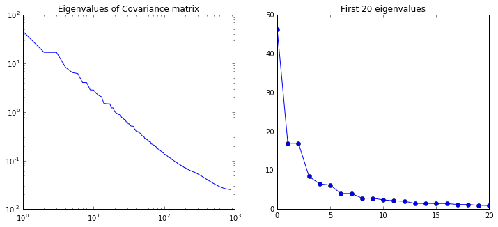

```python
figure(figsize=(12,5))
subplot(121)
loglog(range(1,len(lam)+1), lam, '-')
title('Eigenvalues of Covariance matrix')

subplot(122)
plot(lam, 'o-')
nmodes = 20
xlim(0,nmodes)
title('First %s eigenvalues' % nmodes)
```

### Plot the eigenvectors as slip patterns

Note that eigenvectors have 2-norm equal to 1. The weights in the figures below refer to the $\sqrt{\lambda_k}$ divided by the 2-norm of the mean slip. Recall the K-L expansion is $$ g = \mu^g + \sum_{k=1}^N z_k \sqrt{\lambda_k} v_k. $$ so these weights indicate the 2-norm of the $k$'th term in the series relative to the mean if $z_k=1$ (i.e. one standard deviation away from the mean).

```python
mean_amp_g = sqrt(sum(mean_slip_g**2))
print "Mean of Gaussian has 2-norm = %g, max amplitude = %g" % (mean_amp_g, mean_slip_g.max())
```

```
Mean of Gaussian has 2-norm = 67.2264, max amplitude = 2.36859
```

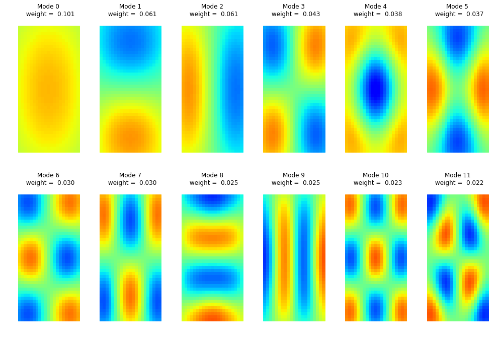

```python
figure(figsize=(17,11))
ni = 2; nj = 6;
for ii in range(ni):
    for jj in range(nj):
        pij = ii*nj + jj
        ax = subplot(ni,nj,pij+1)
        V_amp = sqrt(sum(V[:,pij]**2))
        weight = sqrt(lam[pij]) * V_amp / mean_amp_g
        for j,s in enumerate(new_fault.subfaults):
            s.slip = V[j,pij]
        new_fault.plot_subfaults(ax,slip_color=True,cmin_slip=-0.1,cmax_slip=0.1, plot_box=0., colorbar_shrink=0.)
        title('Mode %s \n weight = %6.3f' % (pij, weight))
        axis('off')
```

### K-L expansion for lognormal

Now we define a function that takes a vector `z` of `N(0,1)` random numbers and returns a slip realization based on the K-L expansion. After computing the sum, exponentiate to get the lognormal:

```python
def KL(z):
    KL_slip = mean_slip_g.copy()  # start with the mean slip
    # add in the terms in the K-L expansion:
    for k in range(len(z)):
        KL_slip += z[k] * sqrt(lam[k]) * V[:,k]

    # exponentiate for lognormal:
    KL_slip = exp(KL_slip)

    # Set the fault slip for the resulting realization:
    for j,s in enumerate(new_fault.subfaults):
        s.slip = KL_slip[j]

    # Rescale to have desired magnitude:
    Mo = new_fault.Mo()
    KL_slip *= Mo_desired/Mo
    for j,s in enumerate(new_fault.subfaults):
        s.slip = KL_slip[j]

    #print "Min slip = %6.2f,  Max slip = %6.2f,  Mw = %6.2f" % (KL_slip.min(), KL_slip.max(), new_fault.Mw())
    return KL_slip
```

### Create a bunch of realizations and display them...

Note: Setting `z[0] = 0` for each realization leaves out 0-th mode `V[:,0]`, which is nearly constant. After exponentiating to get the lognormal, adding a constant to the Gaussian is equivalent to multiplication by a constant, i.e. rescaling the slip and hence the magnitude.

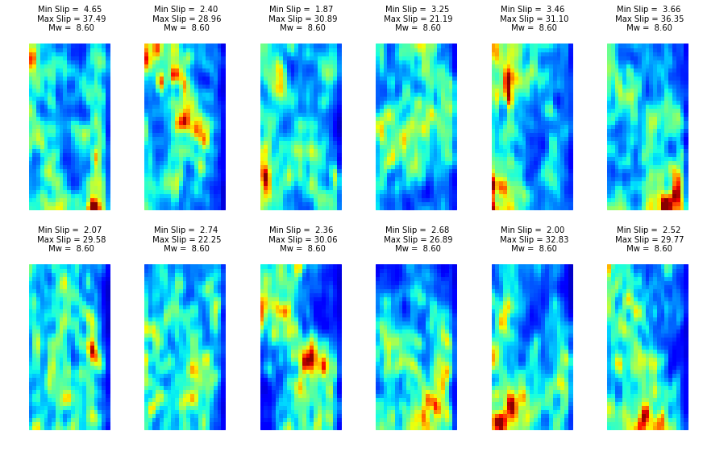

```python
seed = 12345   # so random number generator gives repeatable results
random.seed(seed)

n_modes = 200      # number of eigenmodes to use in each realization

ni = 2; nj = 6;
figure(figsize=(15,3*(ni+1)))

for ii in range(ni):
    for jj in range(nj):
        pij = ii*nj + jj + 1
        ax = subplot(ni,nj,pij)
        z = randn(n_modes)
        #z[0] = 0.  # to keep Mw roughly fixed
        KL_slip = KL(z)
        new_fault.plot_subfaults(ax,slip_color=True, cmax_slip=30., plot_box=False, colorbar_shrink=0)
        axis('off')
        title('Min Slip = %5.2f\n Max Slip = %5.2f\n Mw = %5.2f' \
              % (KL_slip.min(), KL_slip.max(), new_fault.Mw()),fontsize=10)

#savefig('rectangular_lognormal.png')
```

**Note:**

- Slip is always non-negative since lognormal distribution is now used.
- von Karman ACF with small $H$ gives slowly decaying eigenvalues and therefore many modes are needed (and hence high frequencies are visible). However, after applying Okada model these higher modes are rapidly damped and don't appear anyway in sea floor deformation, so this may not be the best model to use for tsunami applications. (Paper in prepartion on this).

## Cascadia Subduction Zone

Now we repeat the above for CSZ. We start with a fault model consisting of 20 subfaults based on the geometry of Pollitz, McCrory, et al., http://doi.wiley.com/10.1111/j.1365-246X.2010.04546.x, which is stored in a csv file:

```
There are 20 subfaults
Subdivided fault has 865 subfaults
```

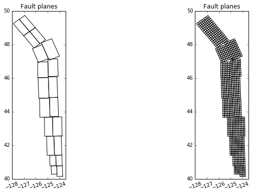

```python
column_map = {"longitude":1, "latitude":2, "depth":3, "strike":4,
              "length":5, "width":6, "dip":7}
defaults = {'rake': 90, 'slip':1.0}
coordinate_specification = 'top center'
input_units = {'slip': 'm', 'depth': 'km', 'length': 'km', 'width': 'km'}
rupture_type = 'static'
skiprows = 1
delimiter = ','

fault = dtopotools.Fault()
fault.read('CSZe01.csv', column_map, coordinate_specification,
           rupture_type,skiprows, delimiter, input_units, defaults)
print "There are %s subfaults" % len(fault.subfaults)

for s in fault.subfaults:
    s.longitude = s.longitude - 360.  # adjust to W coordinates

figure(figsize=(12,6))
ax = subplot(121);
fault.plot_subfaults(ax)
xticks(range(-128,-123));

# Now subdivide each subfault further

new_subfaults = []  # to accumulate all new subfaults

phi_plate = 60.  # angle oceanic plate moves clockwise from north, to set rake

for subfault in fault.subfaults:
    subfault.rake = subfault.strike - phi_plate - 180.
    # subdivide into nstrike x ndip subfaults, based on the dimensions of the fault:
    nstrike = int(subfault.length/12000)
    ndip = int(subfault.width/10000)
    f = dtopotools.SubdividedPlaneFault(subfault, nstrike, ndip)
    new_subfaults = new_subfaults + f.subfaults

# reset fault.subfaults to the new list of all subfaults after subdividing:
new_fault = dtopotools.Fault(subfaults = new_subfaults)
n = len(new_fault.subfaults)
print "Subdivided fault has %s subfaults" % n

ax = subplot(122);
new_fault.plot_subfaults(ax)
xticks(range(-128,-123));
```

```python
D, Dstrike, Ddip = compute_subfault_distances(new_fault)
```

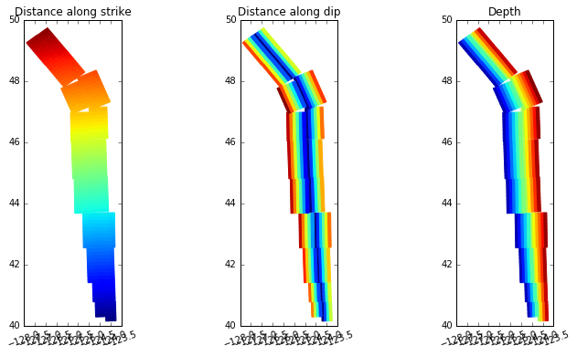

```python
# for debugging, plot distances from lower left subfault
i = 0  # int(N / 2)
for j,s in enumerate(new_fault.subfaults):
    s.slip = Dstrike[i,j]

figure(figsize=(12,6))
ax1 = subplot(131)  #axes([.1,.1,.4,.8])
new_fault.plot_subfaults(ax1,slip_color=True, plot_box=False, colorbar_shrink=0.)
title('Distance along strike')

for j,s in enumerate(new_fault.subfaults):
    s.slip = Ddip[i,j]
ax2 = subplot(132)  #axes([.6,.1,.4,.8])
new_fault.plot_subfaults(ax2,slip_color=True, plot_box=False, colorbar_shrink=0.)
title('Distance along dip')

for j,s in enumerate(new_fault.subfaults):
    s.slip = s.depth
ax3 = subplot(133)
new_fault.plot_subfaults(ax3,slip_color=True, plot_box=False, colorbar_shrink=0.)
title('Depth')
```

**Note:** All of the subfaults closest to the trench have top edge at 1 km depth, and the original subfaults down-dip have top edge at 11 km. This leads to a discontinuity just south of 44 degrees in depth, and so also in the distance along dip computed based on depth, due to the jump in longitude of the subfaults at this point. This then shows up as discontinuities in the eigenmodes below. It would be better to define distances differently (as in earlier version).

```
Correlation lengths: Lstrike = 400000, Ldip = 40000
Hurst exponent = 0.30
```

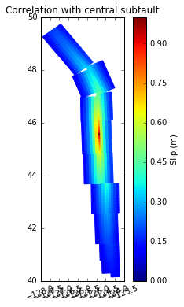

```python
# make correlation matrix:
# Gaussian with correlation lengths Lstrike and Ldip:
Lstrike = 400e3
Ldip = 40e3
H = 0.3  # Hurst exponent

print "Correlation lengths: Lstrike = %g, Ldip = %g" % (Lstrike,Ldip)
print "Hurst exponent = %4.2f" % H
r = sqrt((Dstrike/Lstrike)**2 + (Ddip/Ldip)**2)
C = vonKarman(r,H)

#C = exp(-((Dstrike/Lstrike)**2 + (Ddip/Ldip)**2))

# for debugging, plot correlation with central subfault
i = int(n / 2) - 30
for j,s in enumerate(new_fault.subfaults):
    s.slip = C[i,j]

figure(figsize=(4,6))
ax = axes()
new_fault.plot_subfaults(ax,slip_color=True, plot_box=False)
title('Correlation with central subfault')
```

```
mean_slip 7.25477 meters required for Mw 9.0
Finding eigenmodes from 865 by 865 matrix C
```

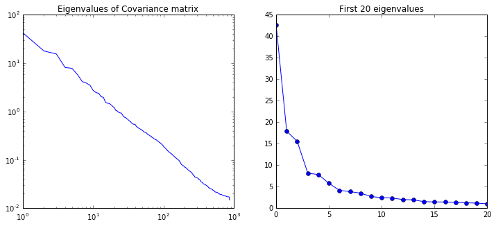

```python
lengths = array([s.length for s in fault.subfaults])
widths = array([s.width for s in fault.subfaults])
areas = lengths * widths
total_area = sum(areas)

Mw_desired = 9.0
Mo_desired = 10.**(1.5*Mw_desired + 9.05)
mean_slip = Mo_desired / (fault.subfaults[0].mu * total_area)
print "mean_slip %g meters required for Mw %s" % (mean_slip, Mw_desired)

# Turn this into a constant vector:
mean_slip = mean_slip * ones(n)

sigma_slip = 0.5 * mean_slip


## Lognormal:
Cov_g = log((sigma_slip/mean_slip) * (C*(sigma_slip/mean_slip)).T + 1.)
mean_slip_g = log(mean_slip) - diag(Cov_g)/2.

# Find eigenvalues, and eigenvector matrix.
# Columns V[:,k] are eigenvectors.

print "Finding eigenmodes from %s by %s matrix C" % (n,n)
lam, V = eig(Cov_g)

eigenvals = real(lam)  # imaginary parts should be at rounding level
V = real(V)

# Sort eigenvalues:
i = list(argsort(lam))
i.reverse()
lam = lam[i]
V = V[:,i]

figure(figsize=(12,5))
subplot(121)
loglog(range(1,len(lam)+1), lam, '-')
title('Eigenvalues of Covariance matrix')

subplot(122)
plot(lam, 'o-')
nmodes = 20
xlim(0,nmodes)
title('First %s eigenvalues' % nmodes)
```

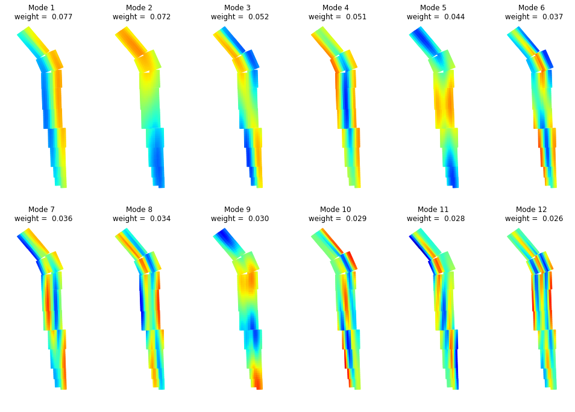

```python
figure(figsize=(17,11))
ni = 2; nj = 6;
for ii in range(ni):
    for jj in range(nj):
        pij = ii*nj + jj + 1
        ax = subplot(ni,nj,pij)
        V_amp = sqrt(sum(V[:,pij]**2))    # abs(V[:,pij]).max()
        weight = sqrt(eigenvals[pij]) * V_amp / mean_amp
        for j,s in enumerate(new_fault.subfaults):
            s.slip = V[j,pij]
        new_fault.plot_subfaults(ax,slip_color=True,cmin_slip=-0.1,cmax_slip=0.1, plot_box=0., colorbar_shrink=0.)
        title('Mode %s \n weight = %6.3f' % (pij, weight))
        axis('off')
```

```python
def KL(z):
    KL_slip = mean_slip_g.copy()  # start with the mean slip
    # add in the terms in the K-L expansion:
    for k in range(len(z)):
        KL_slip += z[k] * sqrt(lam[k]) * V[:,k]

    ## Lognormal:
    KL_slip = exp(KL_slip)

    # Set the fault slip for the resulting realization:
    for j,s in enumerate(new_fault.subfaults):
        s.slip = KL_slip[j]

    # Rescale to have desired magnitude:
    Mo = new_fault.Mo()
    KL_slip *= Mo_desired/Mo
    for j,s in enumerate(new_fault.subfaults):
        s.slip = KL_slip[j]

    #print "Min slip = %6.2f,  Max slip = %6.2f,  Mw = %6.2f" % (KL_slip.min(), KL_slip.max(), new_fault.Mw())
    return KL_slip
```

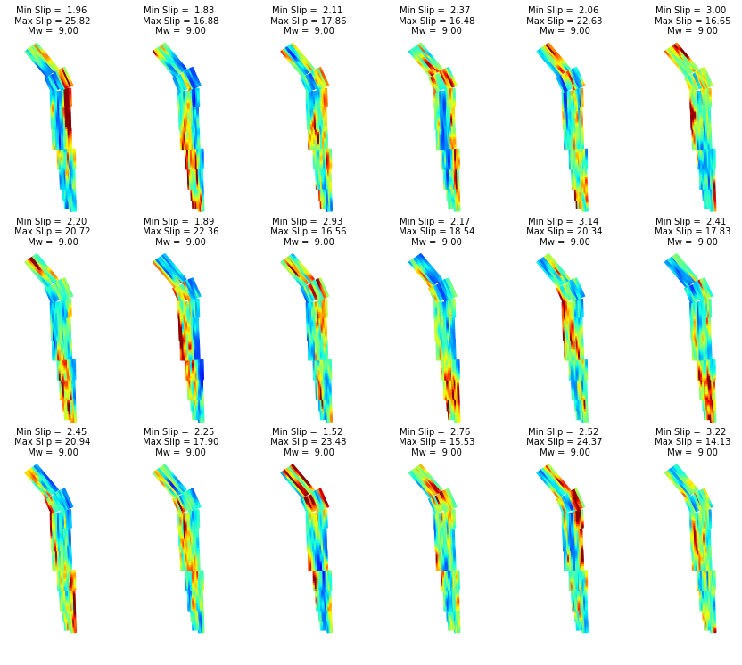

```python
seed = 12347   # so random number generator gives repeatable results
random.seed(seed)

n_modes = 200      # number of eigenmodes to use in each realization

ni = 3; nj = 6;
figure(figsize=(15,3*(ni+1)))

for ii in range(ni):
    for jj in range(nj):
        pij = ii*nj + jj + 1
        ax = subplot(ni,nj,pij)
        z = randn(n_modes)
        # z[0] = 0.  # to keep Mw roughly fixed
        KL_slip = KL(z)
        new_fault.plot_subfaults(ax,slip_color=True, cmax_slip=14., plot_box=False, colorbar_shrink=0)
        axis('off')
        title('Min Slip = %5.2f\n Max Slip = %5.2f\n Mw = %5.2f' \
              % (KL_slip.min(), KL_slip.max(), new_fault.Mw()),fontsize=10)

#savefig('CSZ_lognormal_200.png')
```

### Smoother realizations:

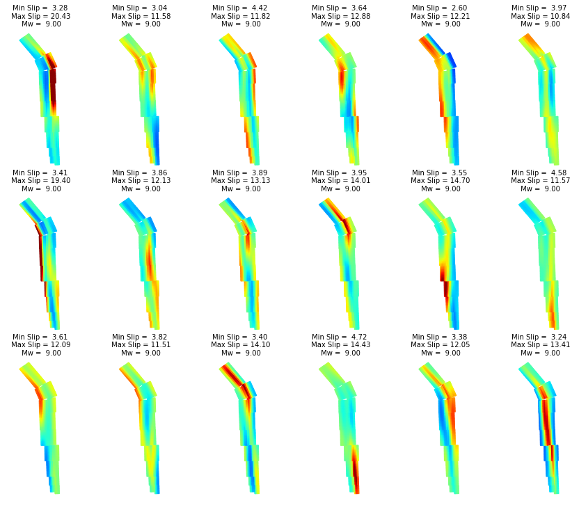

```python
seed = 12347   # so random number generator gives repeatable results
random.seed(seed)

n_modes = 15      # number of eigenmodes to use in each realization

ni = 3; nj = 6;
figure(figsize=(15,3*(ni+1)))

for ii in range(ni):
    for jj in range(nj):
        pij = ii*nj + jj + 1
        ax = subplot(ni,nj,pij)
        z = randn(n_modes)
        z[0] = 0.  # to keep Mw roughly fixed
        KL_slip = KL(z)
        new_fault.plot_subfaults(ax,slip_color=True, cmax_slip=14., plot_box=False, colorbar_shrink=0)
        axis('off')
        title('Min Slip = %5.2f\n Max Slip = %5.2f\n Mw = %5.2f' \
              % (KL_slip.min(), KL_slip.max(), new_fault.Mw()),fontsize=10)

#savefig('CSZ_lognormal_15.png')
```